# project

vh42720

September 23, 2017

### Setting up files and packages

```r
fileUrl <- "https://d396qusza40orc.cloudfront.net/predmachlearn/pml-training.csv"
download.file(fileUrl, destfile = "./pml_training.csv")
fileUrl <- "https://d396qusza40orc.cloudfront.net/predmachlearn/pml-testing.csv"
download.file(fileUrl,destfile = "pml_testing.csv")
lib_names <- list("tidyverse","caret","corrplot","gbm","forecast","rattle","stringr","rebus","rpart")
lapply(lib_names,library,character.only=TRUE)
```

### Loading files

```r
df <- read.csv("pml_training.csv")
test <- read.csv("pml_testing.csv")
```

### Cleaning data

First we will clean out variables that is irrelevant to the study such names, times. We also use near zero variance to weed out more variables. Lastly, we can substitute features with lots of NA with 0 but it will create a near zero variance variable. Thus, we will also delete these features from our dataset.

```r
##Irrelevant variables
pattern <- c("X","user_name","timestamp")
irrIndex <- str_detect(names(df),pattern=or1(pattern))
df <- df[,!irrIndex]
test <- test[,!irrIndex]
##Near zero variance
nzvIndex <- nzv(df,saveMetrics = TRUE)$nzv
df <- df[,!nzvIndex]
test <- test[,!nzvIndex]
##No NA values
naIndex <- colSums(is.na(df))!=0
df <- df[,!naIndex]
test <- test[,!naIndex]
```

### Cross Validation

Now we will separate our df into training (0.8) and testing (0.2) sets. To keep the paper short, we won’t resample more than once.

```r
inTrain <- createDataPartition(df$classe, p=0.8, list=FALSE)
training <- df[inTrain,]
validation <- df[-inTrain,];rm(inTrain)
```

Our Cross Validation setup is as followed: *1. Training set: 15699 observations* 2. Validation set: 3923 observations *3. Test set: 20 observations

### Exploratory Data Analysis

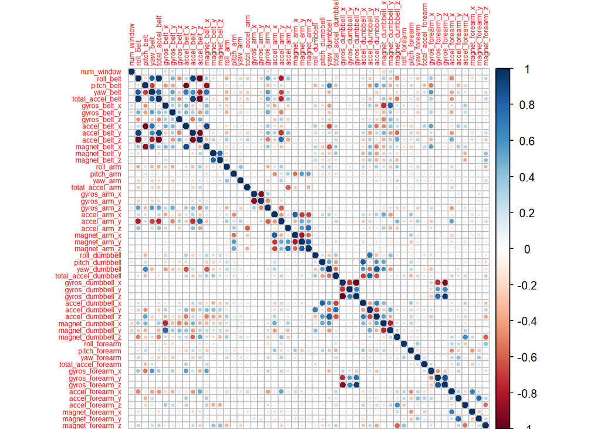

```r
corrplot(cor(training[,-54]),tl.cex = 0.5)
```

There are not many variables correlate to each other

### Model

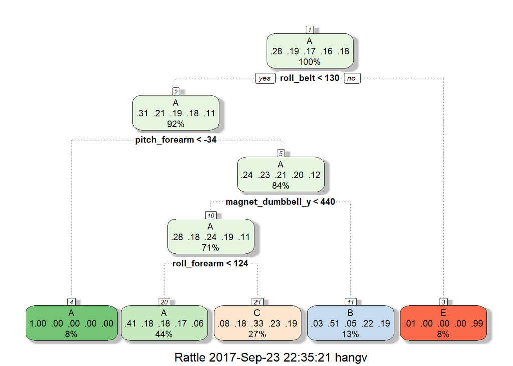

```r
modTree <- train(classe~., method="rpart",data=training)
fancyRpartPlot(modTree$finalModel)
```

```r
predTree <- predict(modTree,validation)
statTree <- c(Accuracy = confusionMatrix(predTree,validation$classe)$overall[[1]],
              out_of_sample_error = 1-confusionMatrix(predTree,validation$classe)$overall[[1]])
statTree
```

```
##            Accuracy out_of_sample_error
##           0.4955391           0.5044609
```

We can see that classification tree somehow completely miss the Class:D which brings its accuracy down subtaintially.

### Random Forest

```r
modForest <- train(classe~., method="rf",data=training)
modForest
```

```
## Random Forest
##
## 15699 samples
##    53 predictor
##     5 classes: 'A', 'B', 'C', 'D', 'E'
##
## No pre-processing
## Resampling: Bootstrapped (25 reps)
## Summary of sample sizes: 15699, 15699, 15699, 15699, 15699, 15699, ...
## Resampling results across tuning parameters:
##
##   mtry  Accuracy   Kappa
##    2    0.9929378  0.9910685
##   27    0.9961222  0.9950963
##   53    0.9921772  0.9901079
##
## Accuracy was used to select the optimal model using  the largest value.
## The final value used for the model was mtry = 27.
```

```r
predForest <- predict(modForest,validation)
statForest <- c(Accuracy = confusionMatrix(predForest,validation$classe)$overall[[1]],
              out_of_sample_error = 1-confusionMatrix(predForest,validation$classe)$overall[[1]])
statForest
```

```
##            Accuracy out_of_sample_error
##        0.9992352791        0.0007647209
```

We can see the Random forest methods give us almost 100% accuracy. However, the big trade off is the running speed. It tooks much longer than classification tree.

### Boosting

Final method is boosting should give almost the same accuracy as random forest and suffers from the same weakness of running time!

```r
modBoost <- train(classe~., method="gbm",data=training,verbose=FALSE)
modBoost
```

```
## Stochastic Gradient Boosting
##
## 15699 samples
##    53 predictor
##     5 classes: 'A', 'B', 'C', 'D', 'E'
##
## No pre-processing
## Resampling: Bootstrapped (25 reps)
## Summary of sample sizes: 15699, 15699, 15699, 15699, 15699, 15699, ...
## Resampling results across tuning parameters:
##
##   interaction.depth  n.trees  Accuracy   Kappa
##   1                   50      0.7581808  0.6930412
##   1                  100      0.8304891  0.7853292
##   1                  150      0.8688239  0.8339597
##   2                   50      0.8823704  0.8510098
##   2                  100      0.9383950  0.9220207
##   2                  150      0.9617667  0.9516057
##   3                   50      0.9302655  0.9117023
##   3                  100      0.9689074  0.9606430
##   3                  150      0.9840545  0.9798203
##
## Tuning parameter 'shrinkage' was held constant at a value of 0.1
##
## Tuning parameter 'n.minobsinnode' was held constant at a value of 10
## Accuracy was used to select the optimal model using  the largest value.
## The final values used for the model were n.trees = 150,
##  interaction.depth = 3, shrinkage = 0.1 and n.minobsinnode = 10.
```

```r
predBoost <- predict(modBoost,validation)
statBoost <- c(Accuracy = confusionMatrix(predBoost,validation$classe)$overall[[1]],
              out_of_sample_error = 1-confusionMatrix(predBoost,validation$classe)$overall[[1]])
statBoost
```

```
##            Accuracy out_of_sample_error
##          0.98827428          0.01172572
```

Our comparison between methods are as followed

```r
rbind(statTree,statForest,statBoost)
```

```
##             Accuracy out_of_sample_error
## statTree   0.4955391        0.5044608718
## statForest 0.9992353        0.0007647209
## statBoost  0.9882743        0.0117257201
```

Based on the accuracy rate, we will choost random forest as the final model to test

### Test results

```r
predict(modForest,test)
```

```
##  [1] B A B A A E D B A A B C B A E E A B B B
## Levels: A B C D E
```